# GBIF Gap Finder — summary report

Data as of 29 July 2026 · rendered 15 October 2026 · Gap Finder v1.0.2

This report is a printable snapshot of the **GBIF Gap Finder** for **Sweden** (https://gbif.se/gap-finder/). It follows the tabs of the app and shows each tab’s main figure at the app’s default settings: all record types, land and sea, all taxa. The app adds filters (taxon, record type, years, publisher type, region) and interactive maps; use it to explore any section further.

Occurrence figures (Spatial, Temporal, Publishers, Record types) count **all GBIF records** for Sweden. Taxonomic and Species of concern figures are measured against the national backbone (Dyntaxa). Records are counted by the date the organism was observed, not the date the data were published.

# Overview

| Dimension | Headline | Detail |
| --- | --- | --- |
| Spatial | 97.8% of 10 km cells have data | 6,170 of 6,308 cells; 138 cells have no records. 148,275,746 occurrences in total. |
| Temporal | 5.3% of cells stale (> 5 years) | Data span 476 years (1551–2026). Median cell staleness 0 months. |
| Taxonomic | 72.3% of backbone species in GBIF | 57,706 of 79,778 species found; 22,072 have no records. |
| Threatened species | 122 missing from GBIF | 4,737 of 4,859 threatened species (CR/EN/VU/NT) found (97.5%). |
| Publishers | 438 publishers | 342 cells depend on a single publisher. |
| Record types | 94.5% human observations | 3.1% preserved specimens; 9 record types in use. |

**Species of concern.** In GBIF: 4,737 of 4,859 threatened, 316 of 337 invasive and 127 of 178 sensitive species. With no GBIF records at all: 15 Critically Endangered, 27 Endangered and 21 invasive species.

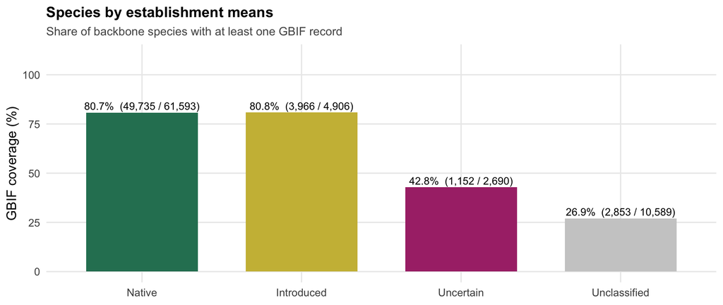

The last 12 months: Aug 2025 – Jul 2026

| Metric | Value |
| --- | --- |
| Observations dated in the period | 6,685,386 |
| Cells with observations | 4,722 |
| Newly covered cells (no earlier records) | 4 |

# Priorities

Where new data would close the largest gaps. The numbers are the same as on the app’s Priorities tab.

| Action | Why |
| --- | --- |
| Spatial: fill zero-coverage cells | 138 grid cells have no GBIF records. |
| Temporal: resurvey stale cells | 329 cells have no GBIF records newer than 5 years. Check for data outside GBIF first. |
| Taxonomic: close species coverage gaps | 22,072 backbone species have no GBIF records. |
| Threatened: monitor CR and EN species | 42 Critically Endangered or Endangered species lack any GBIF record. |
| Native species: improve baseline coverage | Native species coverage is 80.7% (11,858 missing); 21 of 337 invasive species also lack GBIF data. |
| Sensitive species: assess data availability | 178 species have generalised coordinates (5–50 km); 127 have records. |
| Infrastructure: diversify data sources | 342 of 6,308 grid cells depend on a single publisher. |

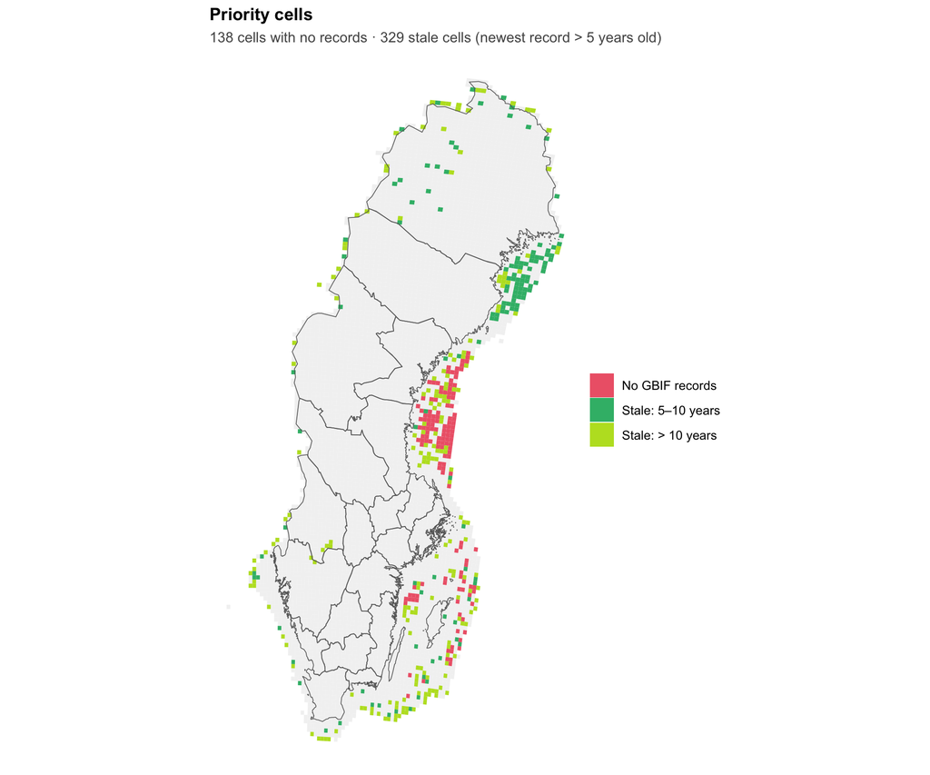

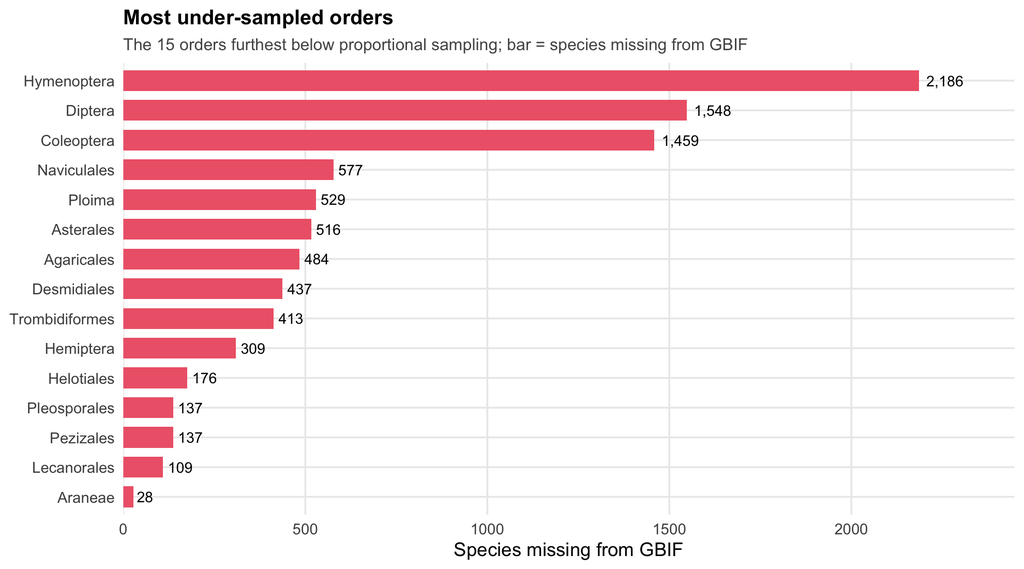

*In the app:* zoom into the zero-coverage and stale-cell maps, download the action plan and the cell lists, and see the under-sampled families.

# Spatial

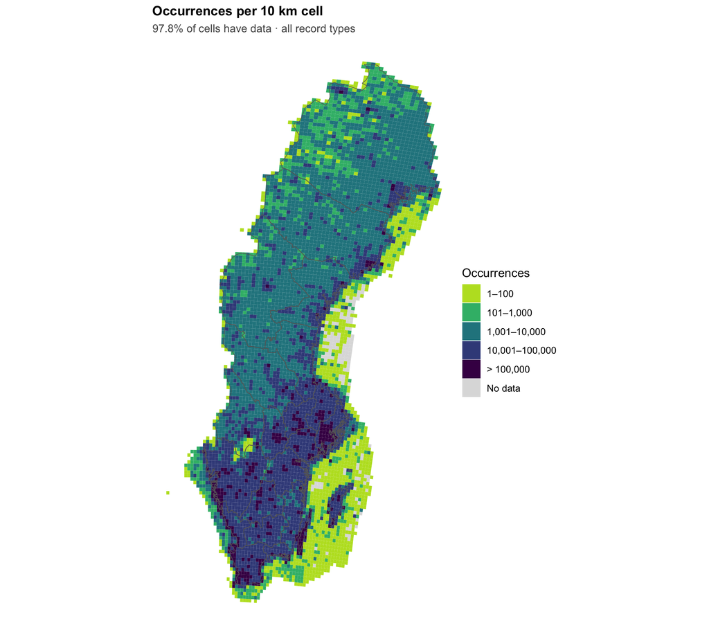

Grid comparison: coverage depends on the cell size

| Grid | Cells | With data | No data | Coverage | Median occurrences per cell |
| --- | --- | --- | --- | --- | --- |
| 10km | 6,308 | 6,170 | 138 | 97.8% | 3,542 |
| 50km | 297 | 297 | 0 | 100.0% | 125,201 |

*In the app:* switch the map to data recency, species richness or the last 12 months; filter by taxon; show county and municipality borders; choose land or sea only.

# Temporal

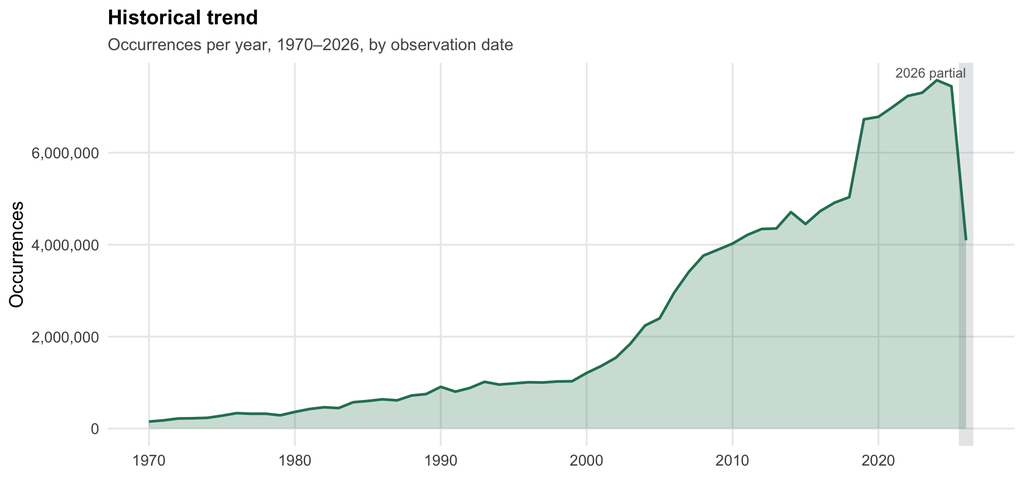

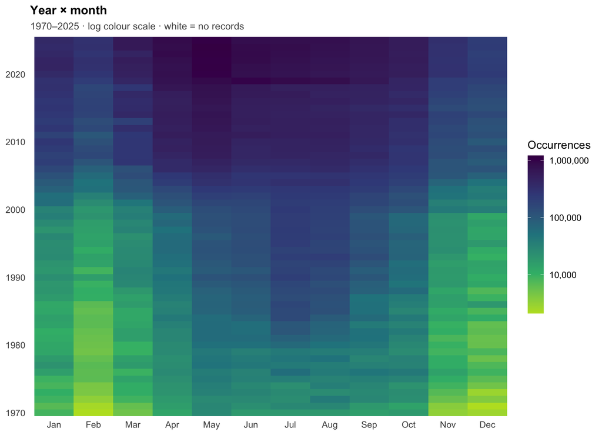

*In the app:* change the year range, filter by taxon or record type, and see the seasonal pattern.

# Taxonomic

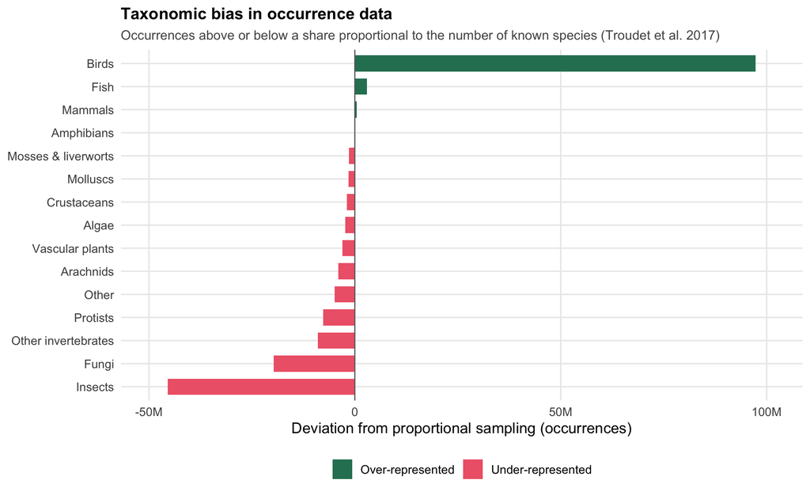

Families with the most species missing from GBIF

| Family | Order | Class | Backbone species | In GBIF | Missing | Coverage |
| --- | --- | --- | --- | --- | --- | --- |
| Ichneumonidae | Hymenoptera | Insecta | 3,328 | 2,699 | 629 | 81.1% |
| Asteraceae | Asterales | Eudicots | 2,888 | 2,399 | 489 | 83.1% |
| Braconidae | Hymenoptera | Insecta | 1,175 | 763 | 412 | 64.9% |
| Desmidiaceae | Desmidiales | Conjugatophyceae | 596 | 191 | 405 | 32.0% |
| Chironomidae | Diptera | Insecta | 887 | 585 | 302 | 66.0% |
| Staphylinidae | Coleoptera | Insecta | 1,516 | 1,274 | 242 | 84.0% |
| Curculionidae | Coleoptera | Insecta | 762 | 550 | 212 | 72.2% |
| Poaceae | Poales | Monocots | 706 | 513 | 193 | 72.7% |
| Eulophidae | Hymenoptera | Insecta | 663 | 480 | 183 | 72.4% |
| Rosaceae | Rosales | Eudicots | 723 | 542 | 181 | 75.0% |

*In the app:* drill down from kingdom to family, compare coverage by order and family, and compare recent with historical sampling.

# Species of concern

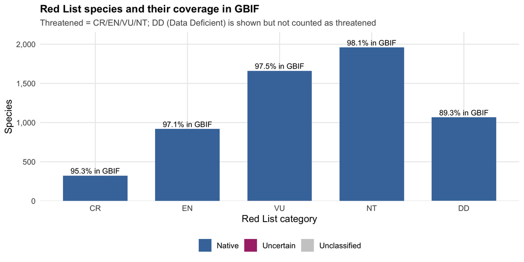

| Group | In backbone | In GBIF | No records |
| --- | --- | --- | --- |
| Threatened (CR/EN/VU/NT) | 4,859 | 4,737 | 122 |
| Invasive | 337 | 316 | 21 |
| Sensitive | 178 | 127 | 51 |

Critically Endangered and Endangered species with no GBIF records (first 25 of 42)

| Species | Status | Class | Order | Family |
| --- | --- | --- | --- | --- |
| Calidris alpina schinzii | CR | Aves | Charadriiformes | Scolopacidae |
| Hieracium remanentiforme | CR | Eudicots | Asterales | Asteraceae |
| Hieracium toerense | CR | Eudicots | Asterales | Asteraceae |
| Taraxacum bavaricum | CR | Eudicots | Asterales | Asteraceae |
| Taraxacum faeroeënse | CR | Eudicots | Asterales | Asteraceae |
| Orobanche purpurea | CR | Eudicots | Lamiales | Orobanchaceae |
| Paracoryphella parva | CR | Gastropoda | Nudibranchia | Paracoryphellidae |
| Aelia rostrata | CR | Insecta | Hemiptera | Pentatomidae |
| Evagetes gibbulus | CR | Insecta | Hymenoptera | Pompilidae |
| Pachypeltis invadens | CR | Lecanoromycetes | Teloschistales | Teloschistaceae |
| Dactylorhiza majalis subsp. baltica | CR | Monocots | Asparagales | Orchidaceae |
| Ophrys apifera | CR | Monocots | Asparagales | Orchidaceae |
| Koeleria grandis | CR | Monocots | Poales | Poaceae |
| Tremella confluens | CR | Tremellomycetes | Tremellales | Tremellaceae |
| Cnemidocarpa mollispina | CR | Unclassified | Stolidobranchiata | Styelidae |
| Ramaria aff. strasseri | EN | Agaricomycetes | Gomphales | Gomphaceae |
| Hieracium cacuminatum | EN | Eudicots | Asterales | Asteraceae |
| Hieracium carcarophyllum | EN | Eudicots | Asterales | Asteraceae |
| Hieracium hastato-ovatum | EN | Eudicots | Asterales | Asteraceae |
| Hieracium helenae | EN | Eudicots | Asterales | Asteraceae |
| Hieracium imbricatum | EN | Eudicots | Asterales | Asteraceae |
| Hieracium maculosiforme | EN | Eudicots | Asterales | Asteraceae |
| Hieracium marginelliceps | EN | Eudicots | Asterales | Asteraceae |
| Hieracium oreades | EN | Eudicots | Asterales | Asteraceae |
| Hieracium planifrons | EN | Eudicots | Asterales | Asteraceae |

*In the app:* the full lists of missing threatened, invasive and sensitive species, their maps, and how each group is recorded.

# Publishers

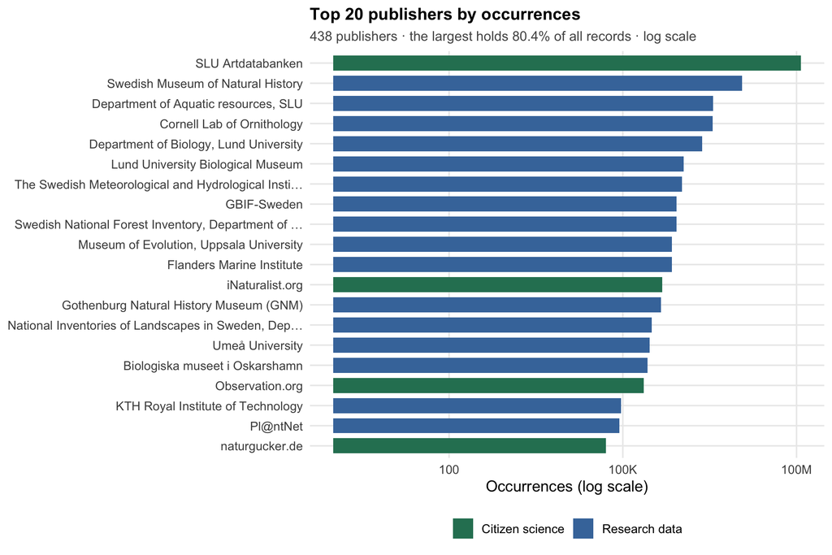

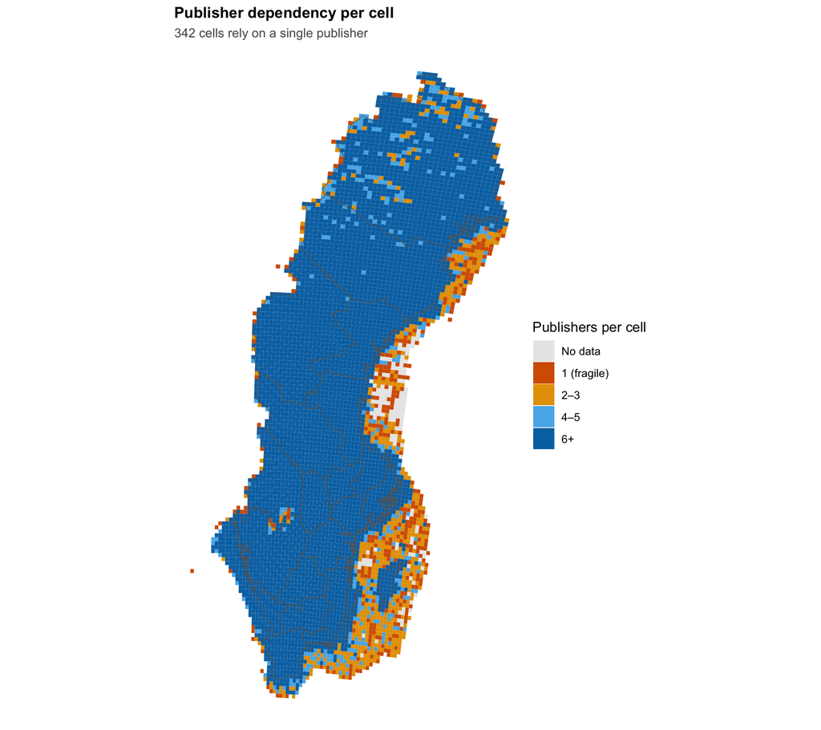

*In the app:* filter by publisher type and taxon, switch to species coverage, and search the full publisher table.

# Record types

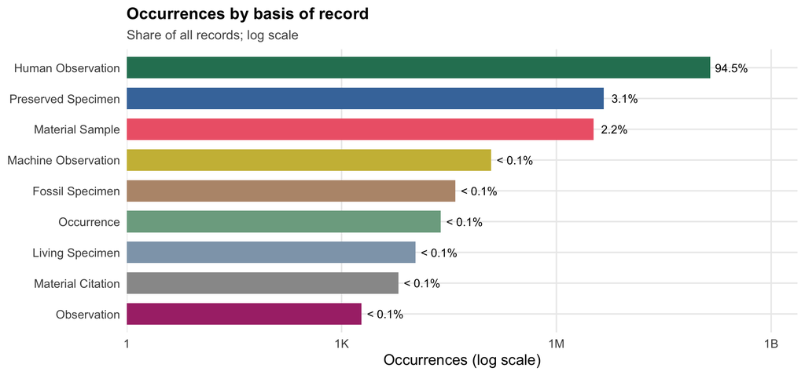

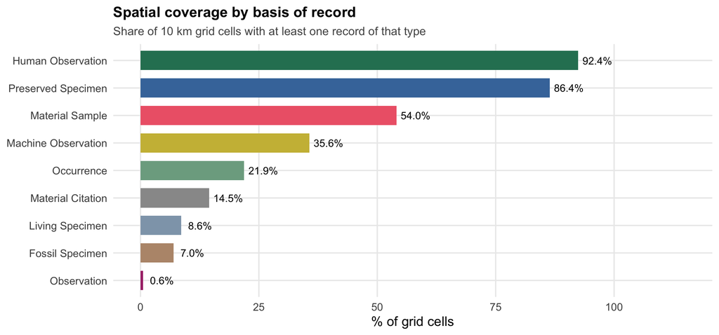

*In the app:* the trend of each record type over time, species per record type, and a map per record type.

# Data & sources

The analysis is built on these GBIF occurrence downloads. If you use these results, please cite them — it is how the data publishers receive credit.

1,285 datasets from 438 publishers contributed records; the app’s **Data & sources** tab lists them with their DOIs.

National reference lists:

- **Taxonomy Backbone**: Dyntaxa. Svensk taxonomisk databas — https://doi.org/10.15468/j43wfc
- **Redlist**: The Swedish Red List 2025 — https://doi.org/10.15468/zbbyqv
- **Invasives**: Global Register of Introduced and Invasive Species - Sweden — https://doi.org/10.15468/i57bff
- **Sensitive**: List of Restricted Access Species In Sweden — https://doi.org/10.15468/jwbtsb
- **COL Backbone**: Catalogue of Life — https://doi.org/10.48580/dgyy9

## How to cite

Thöle, L. M., Holston, K. C., Shah, M., & Johansson, V. A. GBIF Gap Finder: a reproducible pipeline for biodiversity data gap analysis (v1.0.2). GBIF Sweden, Swedish Museum of Natural History (NRM). https://gbif.se/gap-finder/. Source code: https://github.com/GBIF-Sweden/gbif_gap_finder.

Contact: GBIF Sweden, gbif@nrm.se.